# nb04_Subject-Level-Analysis

## First Level for multiple subjects

### A generic first-level analysis script

Using a notebook like this is an effective method for preparing the final analysis script. Now, we can combine all the elements discussed into a unified, generic script that will conduct the first-level analysis.

**Example of a generic first-level script**: code-examples/first_level_script.py

**Things to note:**

- We are saving the result files in BIDS format so that they can be easily queried with PyBIDS for further analysis.
- We are generating a *dataset_description.json* file for the result model, which is required to make the results directory BIDS-compatible. This file will also contain our model parameters, which is useful for understanding how the results were obtained.

**Main steps:**

1. Specify the input and output paths and the subject's ID. The input should be the BIDS dataset, which contains the derivatives folder with fmriprep's preprocessed data.
2. Specify the contrasts (in this example, the contrasts include Faces > Scrambled, Effects of Interest, and single contrasts for each of the nine conditions).
3. Specify the subject's preprocessed functional, event files.
4. Specify the confounds of interest.
5. Specify the first-level model parameters and fit the model.
6. Compute the contrasts and save the results in BIDS format.
7. Create the model's *dataset_description.json* file.

### Processing multiple subjects in parallel

#### Using `SLURM`

If `SLURM`is available on the system, you can create a project-specific script where you define the paths and use the `sbatch` command to execute the generic script for each subject in parallel.

**Example script**: step07_first_level_analysis.sh

If `SLURM` is not available, you can still process multiple subjects in parallel using alternative methods depending on the system you're working with.

#### Using Python's `multiprocessing` Module

Python's `multiprocessing` module allows you to run processes in parallel on your local machine, distributing the workload across multiple CPU cores. An advantage is that it can be run on a single machine without needing a cluster or SLURM. A disatvantage is that it is limited by the local resources (RAM, CPU), and not ideal for very large datasets or many subjects. Here is an example how you could use the `multiprocessing` module:

```
import multiprocessing as mp
import os

# Define a function to process a single subject
def process_subject(subject_id, dataset_location, output_dir):
    # Execute the first-level script with the appropriate arguments
    os.system(f"python first_level_script.py {dataset_location} sub-{subject_id} {output_dir}")

# Define the dataset location and output directory
dataset_location = "/path/to/bids_dataset"
output_dir = "/path/to/output"

# List of subject IDs
subjects = ['01', '02', '03', '04', '05', '06', '07', '08', '09', '10', '11', '12', '13', '14', '15', '16']
# subjects = [f"{i:02d}" for i in range(1, 17)]

# Create a pool of processes using the available CPU cores
if __name__ == '__main__':
    pool = mp.Pool(mp.cpu_count())  # Use all available CPU cores

    # Use pool.starmap to pass multiple arguments to the process_subject function
    pool.starmap(process_subject, [(subject, dataset_location, output_dir) for subject in subjects])

    # Close the pool and wait for the processes to complete
    pool.close()
    pool.join()
```

#### Using Cloud Services

If you don’t have SLURM or a powerful local machine, cloud computing platforms (e.g., AWS, Google Cloud, Microsoft Azure) allow you to run parallel processes with scalable resources. You can set up virtual machines or use a service like AWS Batch or Google Cloud Dataflow to handle parallel jobs across multiple subjects. However, it requires cloud expertise and comes with costs.

## Parametric Modulation

So far, every condition (e.g. `IniFF`, `DelUF`, ...) has been modelled as a regressor whose trial-by-trial amplitude is the same (usually 1) - it only asks *whether* something happened on each trial, convolved with the HRF.

**Parametric modulation** extends this by letting the amplitude of a regressor vary, trial by trial, with a continuous (or ordinal) measure recorded during the task - for example reaction time, a confidence rating, or task difficulty. Nilearn implements this through an optional `modulation` column in the events table: instead of a fixed height of 1, each event's contribution to the regressor is scaled by its `modulation` value before being convolved with the HRF.

This lets us ask a different kind of question - not just *"is there more activity for famous vs. unfamiliar faces?"*, but *"does activity scale with some continuous measure, trial by trial?"*

### A modulator: `response_time`

Besides `onset`, `duration`, and `trial_type`, the event files for this dataset also include a `response_time` column, recording how long the participant took to respond on each trial (participants performed a simple symmetry-judgement cover task on every trial). `response_time` is a genuinely continuous, trial-by-trial measure, and is commonly used as a parametric modulator of task difficulty/decision effort in the fMRI literature - e.g. slower responses are typically associated with **more** activity in decision/effort-related regions, and **less** activity in regions that show a "repetition suppression"-like response to easy/familiar trials.

We build a `response_time` parametric modulator by duplicating every trial under a new `trial_type`, mean-centring `response_time` (per run), and letting nilearn scale that regressor's amplitude accordingly. Trials with a missing response (no `response_time` recorded) are simply excluded from this regressor - they still contribute to the main condition regressors.

```python
# --- Build a parametric-modulation regressor from 'response_time'
events_with_rt_pm = []

for event_file in event_files:
    events = pd.read_csv(event_file, sep='\t')

    # Unmodulated task regressors (the standard trial_type conditions)
    main_events = events.copy()
    main_events['modulation'] = 1

    # Parametric modulator regressor: response_time, mean-centred within this run.
    # Trials with a missing response_time can't contribute a modulation value,
    # so they are dropped from this regressor only (they still appear in main_events).
    rt_events = events.dropna(subset=['response_time']).copy()
    rt_events['trial_type'] = 'response_time'
    rt_events['modulation'] = rt_events['response_time'] - rt_events['response_time'].mean()

    events_with_rt_pm.append(pd.concat([main_events, rt_events], ignore_index=True))

# Inspect the response_time modulator rows for run 1
events_with_rt_pm[0][events_with_rt_pm[0]['trial_type'] == 'response_time'].head()
```

|  | onset | duration | circle_duration | trial_type | trigger | button_pushed | response_time | stim_file | modulation |
| --- | --- | --- | --- | --- | --- | --- | --- | --- | --- |
| 93 | 0.000 | 0.910 | 0.416 | response_time | 5 | 7 | 1.903 | func/f005.bmp | 0.911473 |
| 94 | 3.124 | 0.996 | 0.450 | response_time | 5 | 4 | 1.041 | func/f012.bmp | 0.049473 |
| 95 | 6.564 | 0.830 | 0.577 | response_time | 6 | 4 | 1.300 | func/f012.bmp | 0.308473 |
| 96 | 9.620 | 0.908 | 0.432 | response_time | 17 | 7 | 1.040 | func/s007.bmp | 0.048473 |
| 97 | 12.894 | 0.885 | 0.557 | response_time | 13 | 4 | 1.357 | func/u003.bmp | 0.365473 |

### Fit a first-level model with the `response_time` modulator

Fit a new `FirstLevelModel` using `events_with_rt_pm` (reusing the same GLM parameters, confounds, and sample masks as before), then inspect the design matrix for run 1 - you should now see a separate `response_time` regressor alongside the standard task conditions.

```
[FirstLevelModel.fit] A 'modulation' column was found in the given events data and is used.
```

```
[FirstLevelModel.fit] A 'modulation' column was found in the given events data and is used.
```

```
[FirstLevelModel.fit] A 'modulation' column was found in the given events data and is used.
```

```
[FirstLevelModel.fit] A 'modulation' column was found in the given events data and is used.
```

```
[FirstLevelModel.fit] A 'modulation' column was found in the given events data and is used.
```

```
[FirstLevelModel.fit] A 'modulation' column was found in the given events data and is used.
```

```
[FirstLevelModel.fit] A 'modulation' column was found in the given events data and is used.
```

```
[FirstLevelModel.fit] A 'modulation' column was found in the given events data and is used.
```

```
[FirstLevelModel.fit] A 'modulation' column was found in the given events data and is used.
```

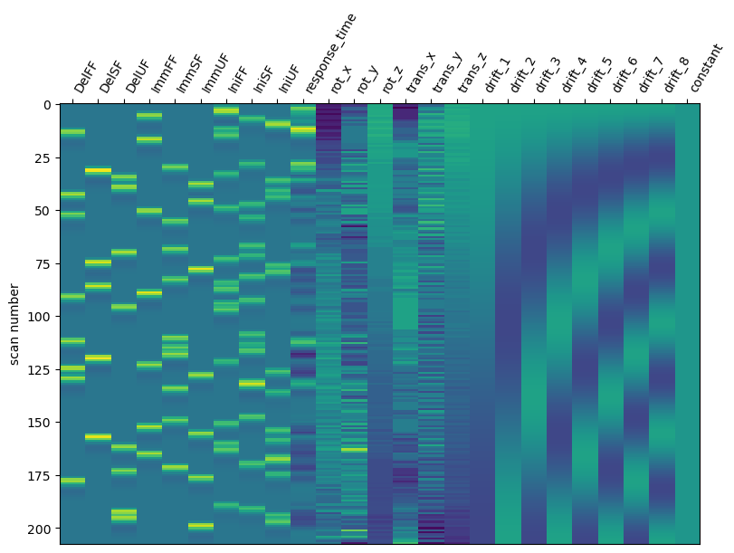

```python
# --- Define and fit the first-level model using the response_time modulator
first_level_model_rt_pm = FirstLevelModel(
    t_r=TR,
    slice_time_ref=slice_time_ref,
    hrf_model='SPM',
    drift_model='cosine',
    high_pass=0.01,
    noise_model='ar1',
    smoothing_fwhm=6,
    mask_img=brain_mask[0]
)

first_level_model_rt_pm = first_level_model_rt_pm.fit(
    preproc_functional_files,
    events=events_with_rt_pm,
    confounds=confounds_for_glm,
    sample_masks=sample_masks_for_glm
)

design_matrices_rt_pm = first_level_model_rt_pm.design_matrices_

# Notice the separate response_time regressor
plot_design_matrix(design_matrices_rt_pm[0])
fig = plt.gcf()
fig.set_size_inches(8, 6)
plt.show()
```

### Test the parametric effect of `response_time`

Build a t-contrast that isolates the `response_time` regressor (one contrast vector per run, since column order/number can differ slightly between runs), then compute and plot the resulting z-map. This shows where BOLD signal scales with how long the participant took to respond, over and above the mean response to each condition.

```
Uncorrected p<.001 threshold: 3.090
```

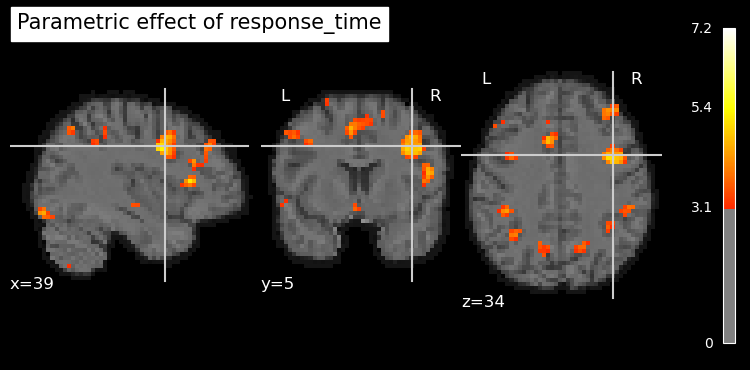

```python
# --- Build a t-contrast for the parametric effect of response_time (one vector per run)
rt_pm_contrasts = []

for design_matrix in design_matrices_rt_pm:
    contrast_vector = np.zeros(design_matrix.shape[1])
    contrast_vector[design_matrix.columns.get_loc('response_time')] = 1
    rt_pm_contrasts.append(contrast_vector)

z_map_rt_pm = first_level_model_rt_pm.compute_contrast(
    rt_pm_contrasts,
    stat_type='t',
    output_type='z_score'
)

# Obtain the statistical threshold
thresholded_z_map_rt_pm, threshold_fpr = threshold_stats_img(
    z_map_rt_pm,
    alpha=.001,
    height_control='fpr',
    two_sided=False
)

print('Uncorrected p<.001 threshold: %.3f' % threshold_fpr)

plot_stat_map(
    thresholded_z_map_rt_pm,
    bg_img=preprocessed_anatomical_file,
    threshold=threshold_fpr,
    display_mode='ortho',
    black_bg=True,
    cmap='hot',
    title='Parametric effect of response_time'
)
plt.show()
```

## Does the effect of `response_time` differ between Famous and Unfamiliar faces?

The single, pooled `response_time` regressor above only tells us about the *average* parametric effect across all conditions (FF, UF, and SF trials combined) - it cannot tell us whether that effect is stronger/weaker for Famous Faces (`FF`) than for Unfamiliar Faces (`UF`).

To test that, we need **separate parametric modulator regressors per face type**, each mean-centred *within its own condition* (not across all trials). Mean-centring within condition is important: it removes each condition's own mean response time from its modulator, so a contrast between the two modulator regressors isolates the *difference in slope* (how strongly the neural response scales with response time) rather than picking up any difference in mean response time or mean activation between conditions (which is already captured by the standard FF/UF condition regressors).

We therefore create three new trial types - `response_time_FF`, `response_time_UF`, `response_time_SF` - one for each face type, and then test the contrast `response_time_FF - response_time_UF`.

```python
# --- Build face-type-specific parametric modulators for response_time
#
# Split the parametric modulator into one regressor per face type
# ('FF', 'UF', 'SF' - matched from the end of the trial_type string, e.g.
# IniFF/ImmFF/DelFF all end with 'FF'). Each modulator is mean-centred
# *within its own condition*, and trials with a missing response_time are
# dropped from that condition's modulator, so a contrast between two of
# these regressors tests a difference in slope, not a difference in mean.

face_type_suffixes = {'FF': 'response_time_FF', 'UF': 'response_time_UF', 'SF': 'response_time_SF'}

events_with_rt_pm_by_facetype = []

for event_file in event_files:
    events = pd.read_csv(event_file, sep='\t')

    # Unmodulated task regressors (the standard trial_type conditions)
    main_events = events.copy()
    main_events['modulation'] = 1

    run_events = [main_events]

    for suffix, pm_trial_type in face_type_suffixes.items():
        subset = events[events['trial_type'].str.endswith(suffix)].dropna(subset=['response_time']).copy()
        subset['trial_type'] = pm_trial_type
        subset['modulation'] = subset['response_time'] - subset['response_time'].mean()
        run_events.append(subset)

    events_with_rt_pm_by_facetype.append(pd.concat(run_events, ignore_index=True))

# Inspect the augmented events for run 1
events_with_rt_pm_by_facetype[0][events_with_rt_pm_by_facetype[0]['trial_type'].str.startswith('response_time')]
```

|  | onset | duration | circle_duration | trial_type | trigger | button_pushed | response_time | stim_file | modulation |
| --- | --- | --- | --- | --- | --- | --- | --- | --- | --- |
| 93 | 0.000 | 0.910 | 0.416 | response_time_FF | 5 | 7 | 1.903 | func/f005.bmp | 0.862806 |
| 94 | 3.124 | 0.996 | 0.450 | response_time_FF | 5 | 4 | 1.041 | func/f012.bmp | 0.000806 |
| 95 | 6.564 | 0.830 | 0.577 | response_time_FF | 6 | 4 | 1.300 | func/f012.bmp | 0.259806 |
| 96 | 19.158 | 0.915 | 0.461 | response_time_FF | 5 | 4 | 2.273 | func/f011.bmp | 1.232806 |
| 97 | 22.265 | 0.907 | 0.421 | response_time_FF | 7 | 4 | 1.314 | func/f005.bmp | 0.273806 |
| ... | ... | ... | ... | ... | ... | ... | ... | ... | ... |
| 181 | 293.467 | 0.833 | 0.582 | response_time_SF | 18 | 7 | 0.951 | func/s003.bmp | -0.112677 |
| 182 | 309.319 | 0.880 | 0.577 | response_time_SF | 19 | 4 | 1.301 | func/s014.bmp | 0.237323 |
| 183 | 334.709 | 0.988 | 0.426 | response_time_SF | 17 | 4 | 0.847 | func/s008.bmp | -0.216677 |
| 184 | 337.932 | 0.967 | 0.463 | response_time_SF | 18 | 4 | 0.660 | func/s008.bmp | -0.403677 |
| 185 | 376.919 | 0.879 | 0.489 | response_time_SF | 17 | 4 | 1.121 | func/s011.bmp | 0.057323 |

93 rows × 9 columns

### Fit a separate model with per-face-type `response_time` modulators

Fit a new `FirstLevelModel` using `events_with_rt_pm_by_facetype`, then inspect the design matrix for run 1 - you should now see three parametric regressors: `response_time_FF`, `response_time_UF`, and `response_time_SF`.

```
[FirstLevelModel.fit] A 'modulation' column was found in the given events data and is used.
```

```
[FirstLevelModel.fit] A 'modulation' column was found in the given events data and is used.
```

```
[FirstLevelModel.fit] A 'modulation' column was found in the given events data and is used.
```

```
[FirstLevelModel.fit] A 'modulation' column was found in the given events data and is used.
```

```
[FirstLevelModel.fit] A 'modulation' column was found in the given events data and is used.
```

```
[FirstLevelModel.fit] A 'modulation' column was found in the given events data and is used.
```

```
[FirstLevelModel.fit] A 'modulation' column was found in the given events data and is used.
```

```
[FirstLevelModel.fit] A 'modulation' column was found in the given events data and is used.
```

```
[FirstLevelModel.fit] A 'modulation' column was found in the given events data and is used.
```

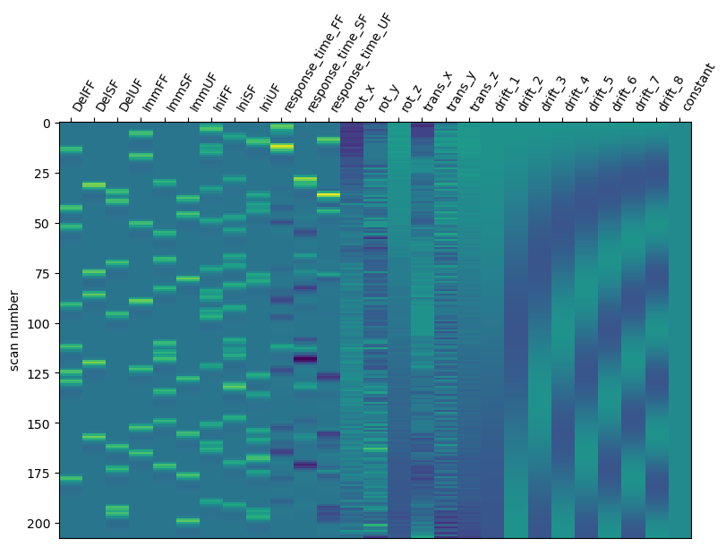

```python
# --- Fit a first-level model using the face-type-specific response_time modulators
first_level_model_rt_facetype_pm = FirstLevelModel(
    t_r=TR,
    slice_time_ref=slice_time_ref,
    hrf_model='SPM',
    drift_model='cosine',
    high_pass=0.01,
    noise_model='ar1',
    smoothing_fwhm=6,
    mask_img=brain_mask[0]
)

first_level_model_rt_facetype_pm = first_level_model_rt_facetype_pm.fit(
    preproc_functional_files,
    events=events_with_rt_pm_by_facetype,
    confounds=confounds_for_glm,
    sample_masks=sample_masks_for_glm
)

design_matrices_rt_facetype_pm = first_level_model_rt_facetype_pm.design_matrices_

# Notice the three separate response_time_FF/UF/SF regressors
plot_design_matrix(design_matrices_rt_facetype_pm[0])
fig = plt.gcf()
fig.set_size_inches(8, 6)
plt.show()
```

### Contrast: Famous vs. Unfamiliar `response_time` effect

Build the contrast `response_time_FF - response_time_UF` (one vector per run) and compute and plot the z-map, testing whether the strength of the RT-related parametric modulation differs between Famous and Unfamiliar faces.

```
Uncorrected p<.001 threshold: 3.291
```

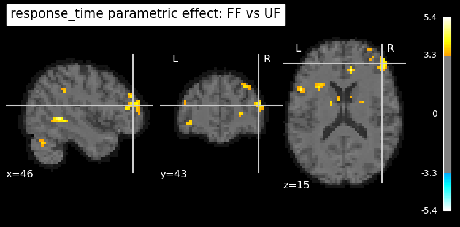

```python
# --- Contrast: does the parametric effect of response_time differ between
# Famous Faces and Unfamiliar Faces? (response_time_FF - response_time_UF)
rt_facetype_pm_diff_contrasts = []

for design_matrix in design_matrices_rt_facetype_pm:
    contrast_vector = np.zeros(design_matrix.shape[1])
    contrast_vector[design_matrix.columns.get_loc('response_time_FF')] = 1
    contrast_vector[design_matrix.columns.get_loc('response_time_UF')] = -1
    rt_facetype_pm_diff_contrasts.append(contrast_vector)

z_map_rt_facetype_pm_diff = first_level_model_rt_facetype_pm.compute_contrast(
    rt_facetype_pm_diff_contrasts,
    stat_type='t',
    output_type='z_score'
)

# Obtain the statistical threshold
_, threshold_fpr = threshold_stats_img(
    z_map_rt_facetype_pm_diff,
    alpha=.001,
    height_control='fpr'
)

print('Uncorrected p<.001 threshold: %.3f' % threshold_fpr)

plot_stat_map(
    z_map_rt_facetype_pm_diff,
    bg_img=preprocessed_anatomical_file,
    threshold=threshold_fpr,
    display_mode='ortho',
    black_bg=True,
    cmap='cold_hot',
    title='response_time parametric effect: FF vs UF'
)
plt.show()
```